# Question 2: Analysis

We need to make a decision regarding the new placement for rewarded Ads. Please report your findings and recommendations with statistical evidence, and help us visualise the results.Our objective is increase the revenue we get from new users throughout their stay in the game while keeping the experience engaging, so the question is simple: should we maintain the control group or deploy the new variant?

first let's start with defining the problem. we should take a look at did we increase the rewarded ads? for proving this hypothesis we first start with general metrics

```python
import pandas as pd
import numpy as np
```

```python
import warnings
warnings.filterwarnings("ignore", category=UserWarning)
warnings.filterwarnings("ignore", category=FutureWarning)
pd.options.mode.chained_assignment = None
```

```python
data = pd.read_csv("(local path)")

data.head()
```

|  | user_id | acquisition_date | date | is_acquired | ab_group | ad_revenue | ad_revenue_interstitial | ad_revenue_rewarded | ad_impressions_interstitial | ad_impressions_rewarded |
| --- | --- | --- | --- | --- | --- | --- | --- | --- | --- | --- |
| 0 | 2788165294615712 | 2022-10-09 | 2022-10-13 | False | test_group | 0.0 | 0.0 | 0.0 | 0 | 0 |
| 1 | 5793823020638738 | 2022-10-17 | 2022-10-17 | False | control_group | 0.0 | 0.0 | 0.0 | 0 | 0 |
| 2 | 5140934416008790 | 2022-10-16 | 2022-10-16 | False | control_group | 0.0 | 0.0 | 0.0 | 0 | 0 |
| 3 | 6118659741496606 | 2022-10-11 | 2022-10-14 | False | control_group | 0.0 | 0.0 | 0.0 | 0 | 0 |
| 4 | 5444473795665560 | 2022-10-08 | 2022-10-13 | True | control_group | 0.0 | 0.0 | 0.0 | 0 | 0 |

```python
data.info()
```

```
<class 'pandas.core.frame.DataFrame'>
RangeIndex: 189326 entries, 0 to 189325
Data columns (total 10 columns):
 #   Column                       Non-Null Count   Dtype
---  ------                       --------------   -----
 0   user_id                      189326 non-null  int64
 1   acquisition_date             189326 non-null  object
 2   date                         189326 non-null  object
 3   is_acquired                  187889 non-null  object
 4   ab_group                     189326 non-null  object
 5   ad_revenue                   189326 non-null  float64
 6   ad_revenue_interstitial      189326 non-null  float64
 7   ad_revenue_rewarded          189326 non-null  float64
 8   ad_impressions_interstitial  189326 non-null  int64
 9   ad_impressions_rewarded      189326 non-null  int64
dtypes: float64(3), int64(3), object(4)
memory usage: 14.4+ MB
```

```python
columns_lst = ["ad_revenue", "ad_revenue_interstitial", "ad_revenue_rewarded", "ad_impressions_interstitial", "ad_impressions_rewarded"]
data[columns_lst].describe()
```

|  | ad_revenue | ad_revenue_interstitial | ad_revenue_rewarded | ad_impressions_interstitial | ad_impressions_rewarded |
| --- | --- | --- | --- | --- | --- |
| count | 189326.000000 | 189326.000000 | 189326.000000 | 189326.000000 | 189326.000000 |
| mean | 0.127953 | 0.089485 | 0.038468 | 1.224856 | 0.383460 |
| std | 0.363963 | 0.268958 | 0.176444 | 3.669922 | 1.749282 |
| min | 0.000000 | 0.000000 | 0.000000 | 0.000000 | 0.000000 |
| 25% | 0.000000 | 0.000000 | 0.000000 | 0.000000 | 0.000000 |
| 50% | 0.000000 | 0.000000 | 0.000000 | 0.000000 | 0.000000 |
| 75% | 0.092713 | 0.073664 | 0.000000 | 1.000000 | 0.000000 |
| max | 10.391798 | 10.386682 | 8.788101 | 149.000000 | 85.000000 |

```python
data = data[data["is_acquired"].isna() == False]
```

```python
#We can also discuss around is there any difference between paid traffic or not but for this time I'll ignore it.
data.groupby('is_acquired')['user_id'].count()
```

```
is_acquired
False    166585
True      21304
Name: user_id, dtype: int64
```

```python
#lets split the data as control and test
control = data[data["ab_group"] == "control_group"]
test = data[data["ab_group"] == "test_group"]
```

```python
#clean outliers
from scipy.stats import zscore
def clean_outliers(df, threshold=3, columns_lst=[]):
    for column in columns_lst:
        df[f"{column}_zscored"] = zscore(df[column])
        df = df[(abs(df[f"{column}_zscored"]) < threshold)]

    return df

control_cleaned = clean_outliers(control, columns_lst=columns_lst)
test_cleaned = clean_outliers(test, columns_lst=columns_lst)
```

```python
test_cleaned.describe()
```

|  | user_id | ad_revenue | ad_revenue_interstitial | ad_revenue_rewarded | ad_impressions_interstitial | ad_impressions_rewarded | ad_revenue_zscored | ad_revenue_interstitial_zscored | ad_revenue_rewarded_zscored | ad_impressions_interstitial_zscored | ad_impressions_rewarded_zscored |
| --- | --- | --- | --- | --- | --- | --- | --- | --- | --- | --- | --- |
| count | 8.278700e+04 | 82787.000000 | 82787.000000 | 82787.000000 | 82787.000000 | 82787.000000 | 82787.000000 | 82787.000000 | 82787.000000 | 82787.000000 | 82787.000000 |
| mean | 4.503773e+15 | 0.037827 | 0.032974 | 0.004853 | 0.450723 | 0.048401 | -0.248306 | -0.220333 | -0.222999 | -0.123172 | -0.174532 |
| std | 2.098608e+15 | 0.073213 | 0.066024 | 0.021620 | 0.898180 | 0.214614 | 0.203323 | 0.470886 | 0.247819 | 0.752566 | 0.483831 |
| min | 1.550221e+13 | 0.000000 | 0.000000 | 0.000000 | 0.000000 | 0.000000 | -0.353357 | -0.455500 | -0.278632 | -0.500823 | -0.283649 |
| 25% | 2.392775e+15 | 0.000000 | 0.000000 | 0.000000 | 0.000000 | 0.000000 | -0.353357 | -0.455500 | -0.278632 | -0.500823 | -0.283649 |
| 50% | 5.339953e+15 | 0.000000 | 0.000000 | 0.000000 | 0.000000 | 0.000000 | -0.353357 | -0.455500 | -0.278632 | -0.500823 | -0.283649 |
| 75% | 5.692404e+15 | 0.067522 | 0.066686 | 0.000000 | 1.000000 | 0.000000 | -0.165837 | 0.020106 | -0.278632 | 0.337056 | -0.283649 |
| max | 2.677187e+16 | 0.455095 | 0.406200 | 0.185426 | 4.000000 | 1.000000 | 0.910512 | 2.441522 | 1.846810 | 2.850692 | 1.970776 |

```python
control_cleaned.describe()
```

|  | user_id | ad_revenue | ad_revenue_interstitial | ad_revenue_rewarded | ad_impressions_interstitial | ad_impressions_rewarded | ad_revenue_zscored | ad_revenue_interstitial_zscored | ad_revenue_rewarded_zscored | ad_impressions_interstitial_zscored | ad_impressions_rewarded_zscored |
| --- | --- | --- | --- | --- | --- | --- | --- | --- | --- | --- | --- |
| count | 8.160200e+04 | 81602.000000 | 81602.000000 | 81602.000000 | 81602.000000 | 81602.000000 | 81602.000000 | 81602.000000 | 81602.000000 | 81602.000000 | 81602.000000 |
| mean | 4.474922e+15 | 0.037816 | 0.032938 | 0.004877 | 0.450173 | 0.048700 | -0.250655 | -0.228411 | -0.226619 | -0.132642 | -0.174618 |
| std | 2.102470e+15 | 0.073386 | 0.065945 | 0.021654 | 0.897307 | 0.215241 | 0.198211 | 0.447966 | 0.244882 | 0.730362 | 0.483419 |
| min | 3.360222e+13 | 0.000000 | 0.000000 | 0.000000 | 0.000000 | 0.000000 | -0.352794 | -0.452161 | -0.281776 | -0.499059 | -0.283995 |
| 25% | 2.368176e+15 | 0.000000 | 0.000000 | 0.000000 | 0.000000 | 0.000000 | -0.352794 | -0.452161 | -0.281776 | -0.499059 | -0.283995 |
| 50% | 5.313923e+15 | 0.000000 | 0.000000 | 0.000000 | 0.000000 | 0.000000 | -0.352794 | -0.452161 | -0.281776 | -0.499059 | -0.283995 |
| 75% | 5.701342e+15 | 0.067522 | 0.066686 | 0.000000 | 1.000000 | 0.000000 | -0.170419 | 0.000837 | -0.281776 | 0.314889 | -0.283995 |
| max | 3.801296e+16 | 0.495522 | 0.402585 | 0.194100 | 4.000000 | 1.000000 | 0.985585 | 2.282587 | 1.913219 | 2.756735 | 1.961947 |

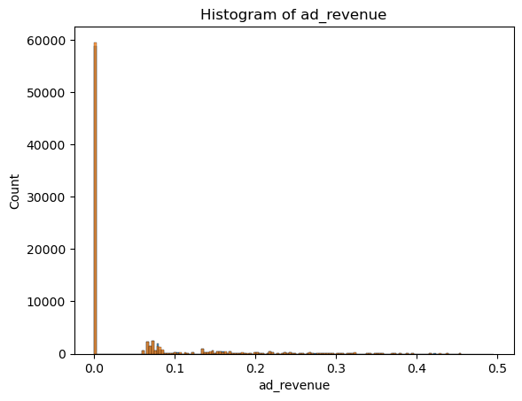

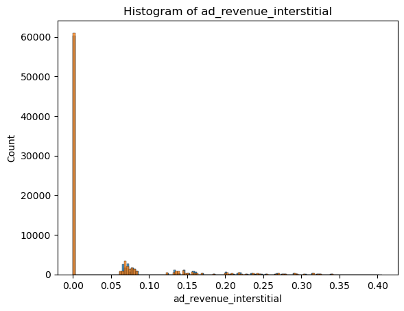

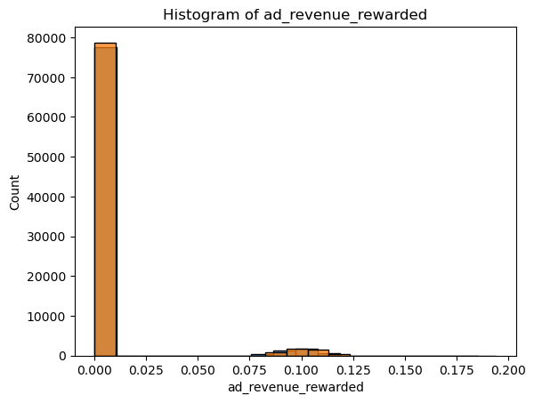

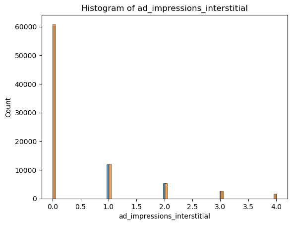

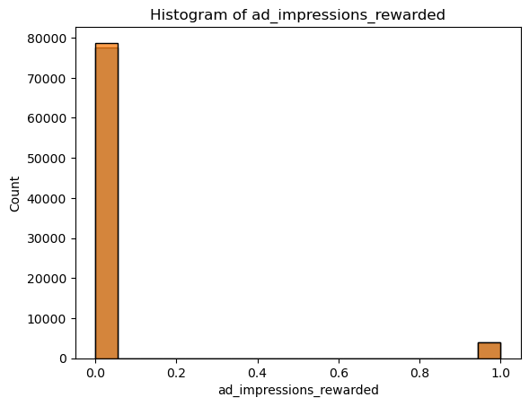

```python
#First compare the distributions of metrics
import seaborn as sns
import matplotlib.pyplot as plt
for column in columns_lst:
    plt.title(f"Histogram of {column}")
    sns.histplot(control_cleaned[column])
    sns.histplot(test_cleaned[column])
    plt.show()
    plt.close()
```

```
control_clicks:  3974
control_views:  81602
variant_clicks:  4007
variant_views:  82787
```

```
Auto-assigning NUTS sampler...
Initializing NUTS using jitter+adapt_diag...
Multiprocess sampling (4 chains in 4 jobs)
NUTS: [control_rate, variant_rate]
```

100.00% [12000/12000 00:01<00:00 Sampling 4 chains, 0 divergences]

```
Sampling 4 chains for 1_000 tune and 2_000 draw iterations (4_000 + 8_000 draws total) took 1 seconds.
```

```
       mean     sd  hdi_3%  hdi_97%  mcse_mean  mcse_sd  ess_bulk  ess_tail  \
delta  -0.0  0.001  -0.002    0.002        0.0      0.0    7925.0    6006.0

       r_hat
delta    1.0
```

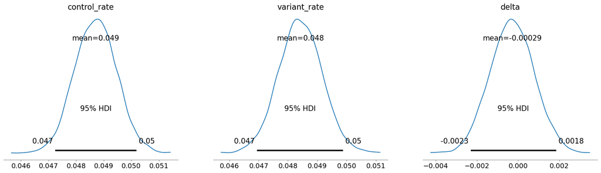

```python
import pymc as pm

# Extract observed data

control_clicks = control_cleaned['ad_impressions_rewarded'].sum()
control_views = len(control_cleaned)
variant_clicks = test_cleaned['ad_impressions_rewarded'].sum()
variant_views = len(test_cleaned)

print("control_clicks: " , control_clicks)
print("control_views: " , control_views)
print("variant_clicks: " , variant_clicks)
print("variant_views: " , variant_views)

# Define the model
with pm.Model() as model:
    # Prior distributions for the proportions
    control_rate = pm.Beta('control_rate', alpha=1, beta=1)
    variant_rate = pm.Beta('variant_rate', alpha=1, beta=1)

    # Likelihoods
    control_successes = pm.Binomial('control_successes', n=control_views, p=control_rate, observed=control_clicks)
    variant_successes = pm.Binomial('variant_successes', n=variant_views, p=variant_rate, observed=variant_clicks)

    # Difference in proportions
    delta = pm.Deterministic('delta', variant_rate - control_rate)

    # Sampling
    trace = pm.sample(2000, tune=1000)

# Summarize the posterior distribution
summary = pm.summary(trace, hdi_prob=0.95)

# Plot the posterior distribution
pm.plot_posterior(trace, hdi_prob=0.95)

#print(summary)

# Make a decision based on the posterior distribution
prob_delta_positive = (summary['mean']['delta'] > 0)
prob_delta_negative = (summary['mean']['delta'] < 0)
if prob_delta_positive:
    print("Probability of variant rate > control rate:", summary['mean']['delta'])
if prob_delta_negative:
    print("Probability of variant rate < control rate:", summary['mean']['delta'])
# Print the summary of the posterior distribution
print(pm.summary(trace, var_names=['delta']))
```

```python
import numpy as np
# Calculate rewarded show and standard error

control_show = sum(control_cleaned['ad_impressions_rewarded']) / len(control_cleaned)
variant_show = sum(test_cleaned['ad_impressions_rewarded']) / len(test_cleaned)

print("control_show: ", control_show)
print("variant_show: ", variant_show)

import math

control_size = len(control_cleaned)
variant_size = len(test_cleaned)

control_se = math.sqrt(control_show * (1 - control_show) / control_size)
variant_se = math.sqrt(variant_show * (1 - variant_show) / variant_size)

print("control_se: ", control_se)
print("variant_se: ", variant_se)


import statsmodels.api as sm

# Perform two-sample z-test
z_stat, p_value = sm.stats.proportions_ztest([control_show * control_size, variant_show * variant_size], [control_size, variant_size])

print("z_stat:", z_stat)
print("p_value", p_value)
# Set the significance level (alpha) and make a decision based on the p-value
alpha = 0.05

if p_value < alpha:
    print("Result: Reject the null hypothesis. There is a significant difference in rewarded video shows between the groups.")
else:
    print("Result: Fail to reject the null hypothesis. There is no significant difference in rewarded video shows between the groups.")
```

```
control_show:  0.04869978676993211
variant_show:  0.04840131904767657
control_se:  0.0007534803404513426
variant_se:  0.0007458894110996341
z_stat: 0.2815185944011087
p_value 0.7783126682667374
Result: Fail to reject the null hypothesis. There is no significant difference in rewarded video shows between the groups.
```

In general data we can both bayesian and frequentist way conclude that there is no significant differences between groups. But it isnot enough to close the case. Anyway let's take a look at is there any differences in cohort day 7 The generated table on the previous question demonstrates us that we can chose install dates between 2022-10-07 and 2022-10-14

```python
day7_test_cleaned = test_cleaned[
    (test_cleaned["acquisition_date"] >= "2022-10-07") &
    (test_cleaned["acquisition_date"] <= "2022-10-14")]
day7_control_cleaned = control_cleaned[
    (control_cleaned["acquisition_date"] >= "2022-10-07") &
    (control_cleaned["acquisition_date"] <= "2022-10-14")]
```

```
control_clicks:  acquisition_date
2022-10-07    405
2022-10-08    334
2022-10-09    410
2022-10-10    381
2022-10-11    280
2022-10-12    316
2022-10-13    324
2022-10-14    340
Name: ad_impressions_rewarded, dtype: int64
control_views:  55414
variant_clicks:  acquisition_date
2022-10-07    405
2022-10-08    334
2022-10-09    410
2022-10-10    381
2022-10-11    280
2022-10-12    316
2022-10-13    324
2022-10-14    340
Name: ad_impressions_rewarded, dtype: int64
variant_views:  57337
```

```
Auto-assigning NUTS sampler...
Initializing NUTS using jitter+adapt_diag...
Multiprocess sampling (4 chains in 4 jobs)
NUTS: [control_rate, variant_rate]
```

100.00% [12000/12000 00:01<00:00 Sampling 4 chains, 0 divergences]

```
Sampling 4 chains for 1_000 tune and 2_000 draw iterations (4_000 + 8_000 draws total) took 1 seconds.
```

```
       mean   sd  hdi_3%  hdi_97%  mcse_mean  mcse_sd  ess_bulk  ess_tail  \
delta  -0.0  0.0  -0.001      0.0        0.0      0.0    8898.0    6161.0

       r_hat
delta    1.0
```

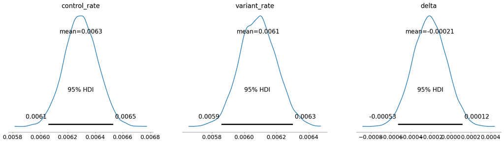

```python
# Extract observed data

control_clicks = day7_test_cleaned.groupby('acquisition_date')['ad_impressions_rewarded'].sum()
control_views = len(day7_control_cleaned)
variant_clicks = day7_test_cleaned.groupby('acquisition_date')['ad_impressions_rewarded'].sum()
variant_views = len(day7_test_cleaned)

print("control_clicks: " , control_clicks)
print("control_views: " , control_views)
print("variant_clicks: " , variant_clicks)
print("variant_views: " , variant_views)

# Define the model
with pm.Model() as model:
    # Prior distributions for the proportions
    control_rate = pm.Beta('control_rate', alpha=1, beta=1)
    variant_rate = pm.Beta('variant_rate', alpha=1, beta=1)

    # Likelihoods
    control_successes = pm.Binomial('control_successes', n=control_views, p=control_rate, observed=control_clicks)
    variant_successes = pm.Binomial('variant_successes', n=variant_views, p=variant_rate, observed=variant_clicks)

    # Difference in proportions
    delta = pm.Deterministic('delta', variant_rate - control_rate)

    # Sampling
    trace = pm.sample(2000, tune=1000)

# Summarize the posterior distribution
summary = pm.summary(trace, hdi_prob=0.95)

# Plot the posterior distribution
pm.plot_posterior(trace, hdi_prob=0.95)

#print(summary)

# Make a decision based on the posterior distribution
prob_delta_positive = (summary['mean']['delta'] > 0)
prob_delta_negative = (summary['mean']['delta'] < 0)
if prob_delta_positive:
    print("Probability of variant rate > control rate:", summary['mean']['delta'])
if prob_delta_negative:
    print("Probability of variant rate < control rate:", summary['mean']['delta'])
# Print the summary of the posterior distribution
print(pm.summary(trace, var_names=['delta']))
```

```python
# Calculate CTR and standard error
from scipy import stats
control_show = day7_control_cleaned.groupby('acquisition_date')['ad_impressions_rewarded'].sum()
variant_show = day7_test_cleaned.groupby('acquisition_date')['ad_impressions_rewarded'].sum()

print("control_show: ", control_show)
print("variant_show: ", variant_show)

t_statistic, p_value = stats.ttest_ind(control_show, variant_show)

print("t_statistic:", t_statistic)
print("p_value", p_value)
# Set the significance level (alpha) and make a decision based on the p-value
alpha = 0.05

if p_value < alpha:
    print("Result: Reject the null hypothesis. There is a significant difference in rewarded video shows between the groups.")
else:
    print("Result: Fail to reject the null hypothesis. There is no significant difference in rewarded video shows between the groups.")
```

```
control_show:  acquisition_date
2022-10-07    372
2022-10-08    351
2022-10-09    339
2022-10-10    403
2022-10-11    248
2022-10-12    320
2022-10-13    307
2022-10-14    316
Name: ad_impressions_rewarded, dtype: int64
variant_show:  acquisition_date
2022-10-07    405
2022-10-08    334
2022-10-09    410
2022-10-10    381
2022-10-11    280
2022-10-12    316
2022-10-13    324
2022-10-14    340
Name: ad_impressions_rewarded, dtype: int64
t_statistic: -0.7261863182974975
p_value 0.47969018538200414
Result: Fail to reject the null hypothesis. There is no significant difference in rewarded video shows between the groups.
```